# Pre processing GSE125416

GSE125416 is an experiment comparing normal hESC cells and nicotine exposed hESC cells. High rate of cell cycle is expected. It contains two samples:

- GSM3573649 Control_EB scRNA-seq [D];
- GSM3573650 nicotine-exposed_EB scRNA-seq [N].

Data is accessible at [Gene Expression Omnibus - GSE125416](https://www.ncbi.nlm.nih.gov/geo/query/acc.cgi?acc=GSE125416).

Article is accessible at [Stem Cell Reports - Single-Cell RNA Sequencing of Human Embryonic Stem Cell Differentiation Delineates Adverse Effects of Nicotine on Embryonic Development](https://www.sciencedirect.com/science/article/pii/S2213671119300244)

# Read data

We use Seurat to read and preprocess the data.

```r
library(Seurat)
filepath = "/home/shaoheng/Documents/data/hESC-droplet/GSE125416/GSM3573649_D_filtered_gene_bc_matrices_h5.h5"
obj = CreateSeuratObject(Read10X_h5(filepath), project='wt')
```

```
Feature names cannot have underscores ('_'), replacing with dashes ('-')
```

```r
obj
```

```
An object of class Seurat
33694 features across 6847 samples within 1 assay
Active assay: RNA (33694 features)
```

# Filtering

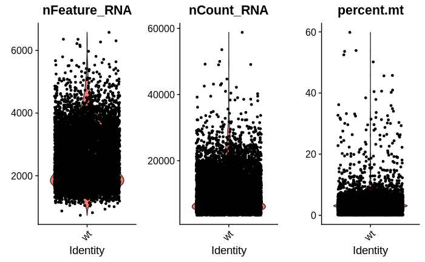

```r
obj[["percent.mt"]] <- PercentageFeatureSet(obj, pattern = "^MT-")
VlnPlot(obj, features = c("nFeature_RNA", "nCount_RNA", "percent.mt"), ncol = 3)
```

## Mitochondria and expressed genes

“cells with fewer than 200 or more than 6,000 expressed genes, and a high percentage of mitochondrial genes (>20%) were removed.” This is done by `subset`. Should keep 6766 cells.

```r
obj <- subset(obj, subset = nFeature_RNA >= 200 & nFeature_RNA <= 6000 & percent.mt < 20)
obj
```

```
An object of class Seurat
33694 features across 6766 samples within 1 assay
Active assay: RNA (33694 features)
```

## Normalization

“We next normalized the gene expression values for each cell by the total expression, multiplied by 10,000, and made a log-transformation.” This is done by `NormalizeData`.

```r
#obj <- NormalizeData(obj)
```

## Variable genes

Variable expressed genes across the single cells under cutoff with an average expression of more than 0.0125 and less than 3, and dispersion of more than 0.5, were detected for down-stream analysis.

```r
obj <- FindVariableFeatures(obj, mean.cutoff = c(0.0125, 3), dispersion.cutoff = c(0.5, Inf))
```

## Cell cycle

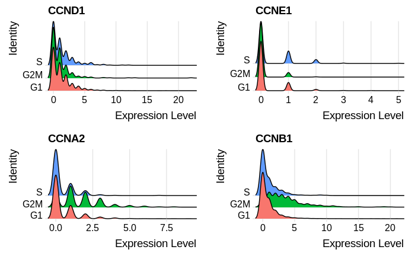

```r
obj <- CellCycleScoring(obj, s.features = cc.genes$s.genes, g2m.features = cc.genes$g2m.genes, set.ident = TRUE)
RidgePlot(obj, features = c("CCND1", "CCNE1", "CCNA2", "CCNB1"), ncol = 2)
```

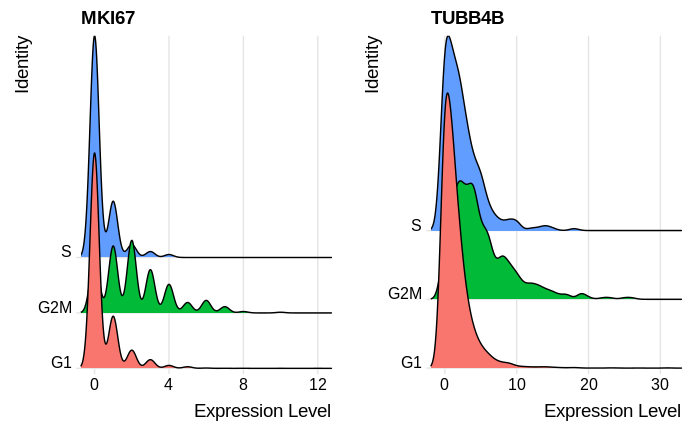

```r
RidgePlot(obj, features = c("MKI67", "TUBB4B"), ncol = 2)
```

## PCA

```r
obj <- ScaleData(obj, features = rownames(obj))
```

```r
obj <- RunPCA(obj, features = VariableFeatures(object = obj))
```

```
PC_ 1
Positive:  DLK1, PRSS23, COL2A1, ZNF436-AS1, SIX6, VIM, PAX6, LHX2, SOX3, FABP7
       NR2F1, TMSB15A, CRB2, IGFBP5, FGF8, RAX, NNAT, ZNF503, RP11-89K21.1, TTC3
       PAX2, KLHDC8A, SMOC1, DCT, LAMP5, METRN, CDH2, EFEMP1, EFNA5, MEG3
Negative:  PFN1, PTMA, NDUFA4, UQCRH, COX5A, RPL8, SLIRP, HSPE1, OAZ1, CLDN6
       RPL12, TPI1, CD24, TIMM13, POU5F1, PRDX1, RPSA, RAN, CARHSP1, SLC25A6
       TOMM7, TMSB4X, ACTB, PSMB6, AURKAIP1, POMP, TXN, NDUFAB1, CYCS, GSTP1
PC_ 2
Positive:  TUBA1B, PRTG, SIX3, HMGB2, MEST, CRNDE, ARL4C, SFRP1, TMSB15A, CENPF
       NUCKS1, ARL6IP1, CALM2, METRN, FRZB, TOP2A, TPBG, SMC4, TUBA1A, GPC3
       NUSAP1, MALAT1, VIM, MKI67, CCNB2, PTTG1, CDKN3, UBE2C, FEZF1, TUBB4B
Negative:  TDGF1, POU5F1, RP11-1144P22.1, RP11-568A7.4, PLA2G16, PIM2, LINC00678, TERF1, UTF1, FOXH1
       NMRK2, PMAIP1, FOXD3-AS1, NANOG, PODXL, DPPA4, FXYD5, APELA, DNMT3B, CD24
       GRID2, RP11-20D14.6, IFITM1, LINC01405, RBPMS2, HEY2, IFITM3, MRS2, RP11-267L5.1, CHCHD10
PC_ 3
Positive:  S100A11, ANXA2, KRT19, CLDN4, KRT8, NEAT1, S100A16, ANXA3, ANXA1, LGALS3
       S100A10, KRT18, ELF3, LMNA, GATA3, PRSS8, RHOC, PERP, SAT1, CLDN3
       UBC, CLDN7, VAMP8, PLAU, CDKN1A, PLD3, DSP, RAB25, AHNAK, SGCG
Negative:  CKS2, CKS1B, UBE2S, BIRC5, RANBP1, USP44, PTTG1, FAM64A, CENPF, HMGB2
       UBE2C, CALM2, NUCKS1, TOP2A, SFRP1, HSPE1, ATP5G1, HN1, DNMT3B, HMGB1
       MKI67, TERF1, SLIRP, RP11-568A7.4, CYCS, MT-ATP6, TIMM13, MT-CO3, PRELID1, ATP5I
PC_ 4
Positive:  LY6E, MT-CYB, HAPLN1, TMSB10, MT-CO3, MT-CO2, IRX2, KRT8, TMEM54, MT-ND2
       MT-ND3, MT-ATP6, MT-CO1, PTPRF, MT-ND1, DBI, TFAP2A, STOM, GATA3, MT-ND4
       SEMA3E, CDH1, CYB5A, KRT19, TMSB4X, PKDCC, C5orf38, KRT18, FGFR3, FSTL1
Negative:  EIF1, TCEA1, SARS, ZFAS1, BBC3, SQSTM1, STC2, VIM, DDIT3, H1F0
       SLC3A2, DDIT4, SHMT2, NEU1, ENO2, BLVRB, ATF5, EMP3, DLK1, CNIH4
       GARS, CEBPB, UBC, BBS9, HLA-A, MALAT1, CDKN1A, MTHFD2, GPR143, C9orf135
PC_ 5
Positive:  ZFAS1, RPL12, MALAT1, FTH1, FTL, C6orf48, RPSA, EPB41L4A-AS1, MT-ND4, MT-ND1
       PIF1, MIAT, RPL8, SLC25A6, MT-CO1, CENPA, MDM4, METRN, SEMA6A, LIN28A
       NEAT1, NR6A1, ARL4C, TMSB4X, SNHG8, MT-ND2, TMSB10, TOMM7, SOX11, MT-CO3
Negative:  CCT5, HSP90AA1, HSP90AB1, SSB, PHGDH, ATP5B, PSMA4, PDIA3, PA2G4, MDH1
       PRDX1, ENO1, EIF4A3, PSMB1, TALDO1, DCAF13, NASP, ACAT2, HSPD1, PDHB
       CDC123, PSMD6, NOP58, PSMC4, HSPA5, HSP90B1, PSMA3, PDHA1, TUBA1B, CACYBP
```

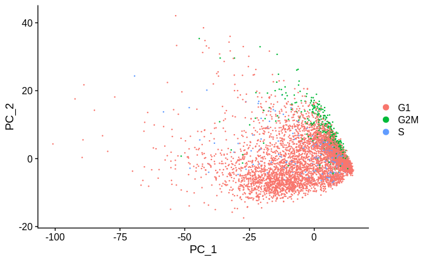

```r
DimPlot(obj)
```

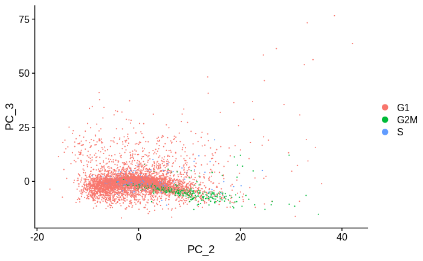

```r
DimPlot(obj, dims = c(2, 3), pt.size=0.1)
```

```r
saveRDS(obj, "~/Documents/data/hESC-droplet/GSE125416/GSM357649-nonorm.RDS")
```

```r
source("../utils/gsea.R")
mat2cls(as.matrix(obj@reductions$pca@cell.embeddings), "~/Documents/data/hESC-droplet/GSE125416/GSM357649-nonorm-pca.cls")
```

```r
source("../utils/hdfrw.R")
mat2hdf(as.matrix(obj@assays$RNA@scale.data), "~/Documents/data/hESC-droplet/GSE125416/GSM357649-nonorm.h5")
```